# Circular Data Analysis and Visualizations with R

Developed for the paper: *Sites of Circadian Clock Neuron Plasticity Mediate Sensory Integration and Entrainment*

Fernández MP https://www.fernandez-lab.org/ (Barnard College and the CUNY Advanced Science Research Center.)https://asrc.gc.cuny.edu/ , Pettibone HL (MCDB, University of Michigan, Ann Arbor.) , Roell CJ (MCDB, University of Michigan, Ann Arbor.) , Davey C (MCDB, University of Michigan, Ann Arbor.) , Huynh KV (MCDB, University of Michigan, Ann Arbor.) , Lennox S (MCDB, University of Michigan, Ann Arbor.) , Kostadinov B (NYC College of Technology, CUNY.) , Shafer OT https://asrc.gc.cuny.edu/people/orie-shafer/ (The CUNY Advanced Science Research Center and MCDB, University of Michigan, Ann Arbor.)https://asrc.gc.cuny.edu/  
2/14/2020

# Introduction

We use [R](https://www.r-project.org/) and [RStudio](https://rstudio.com/) for all data analysis and visualizations. The phase data are available in the paper cited above, and for the purpose of this data analysis we recorded it in the file `phases.csv`. The source [R Markdown](https://rmarkdown.rstudio.com/) document (with `Rmd` extension) containing all R code is also available in the [GitHub repository](https://github.com/bkostadi/circular_analysis).

The key R package that we use for all circular data analysis and visualizations is [**circular**](https://www.rdocumentation.org/packages/circular/versions/0.4-93). All R packages must be installed first before they are loaded with `library()`.

```r
# load the R packages
library(readr) # for reading data
library(circular) # main computing package
library(scales) # for plot colors support
# load the phase data, which is available in the cited paper
phases <- read_csv("phases.csv")
```

```r
# take phases modulo 24 to remove negative phases and convert to radians
radphases <- (phases %% 24)*pi/12 # hours in 00:24 and then radians in 0:2pi
cirradphases <- circular(radphases, units = "radians", template = "clock24",
                         modulo="2pi", zero=pi/2) # or zero=2*pi
```

# Plot 1: PdfGal4, uasUNC5 and pdf>UNC5

In this figure, we show the raw circular data plots and rose diagrams of **PdfGal4**, **uasUNC5** and **pdf>UNC5**, based on the angles in radians, obtained from the phases.

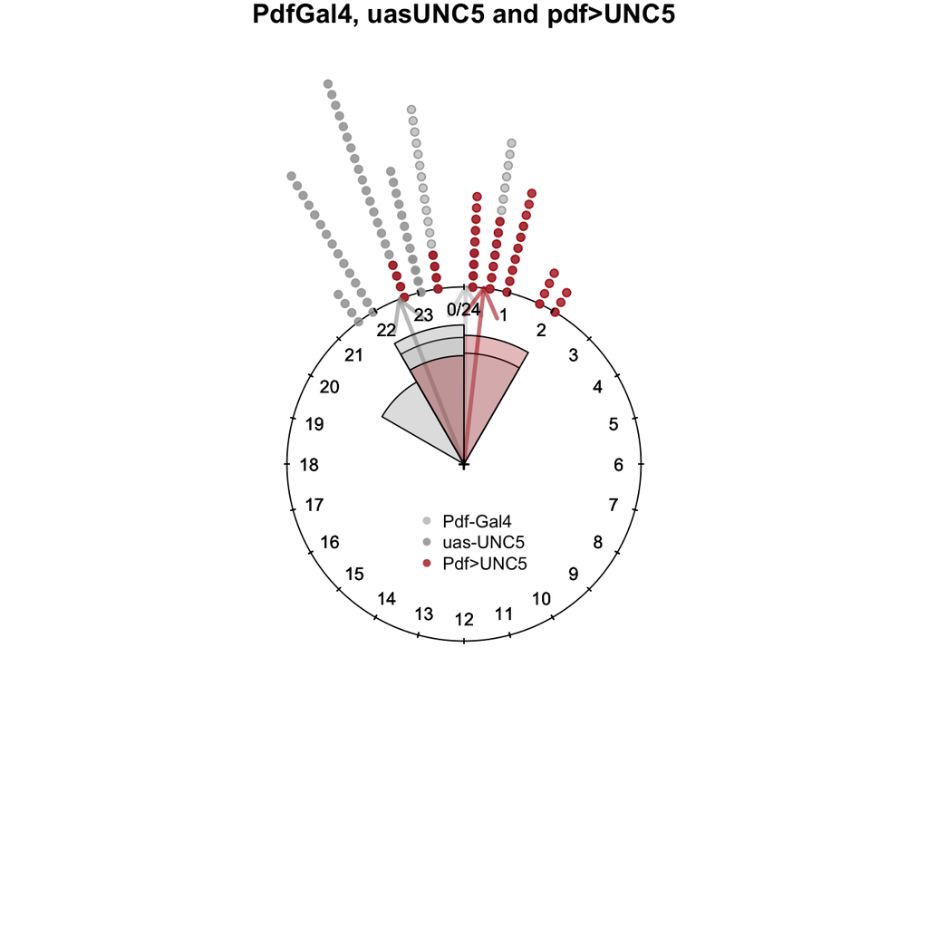

```r
# Plot 1
par(mar=c(rep(1,4))) # set up plot margins
# plot the circular data as a histogram with stack= TRUE
plot(cirradphases[,1], stack = TRUE, pch = 21, bg = alpha("gray77",0.8), col="darkgray", cex=0.8, sep = 0.08,
     shrink = 2.2,main="PdfGal4, uasUNC5 and pdf>UNC5",cex.main=0.8) # plot PdfGal4 [,1]

# calculate the circular means and point to them by arrows
circ.mean1<-mean(cirradphases[,1],na.rm = TRUE)
circ.mean2<-mean(cirradphases[,2],na.rm = TRUE)
circ.mean3<-mean(cirradphases[,3],na.rm = TRUE)

# adding points for uasUNC5 [,2] and pdf>UNC5 [,3]
points(cirradphases[,2],stack = TRUE, pch = 21, bg = alpha("gray60",0.8), col = "darkgray", cex=0.8, sep=0.08)
points(cirradphases[,3],stack=TRUE, pch = 21, bg = alpha("firebrick",0.8), col = "firebrick", cex=0.8, sep=0.08)

# adding arrows to circular means
arrows.circular(circ.mean1, col = alpha("gray77",0.6), lwd=3) # arrow to circ. mean
arrows.circular(circ.mean2, col = alpha("gray60",0.6), lwd=3) # arrow to circ. mean
arrows.circular(circ.mean3, col = alpha("firebrick",0.6), lwd=3) # arrow to circ. mean
legend(-0.3,-0.2,legend=c("Pdf-Gal4", "uas-UNC5","Pdf>UNC5"),
       col=c(alpha("gray77",0.9),alpha("gray60",0.8),alpha("firebrick",0.8)), pch=16,cex=0.8,box.lty=0)
# Rose diagrams
rose.diag(cirradphases[,1],bins=12,col=alpha("gray77",0.3),cex=0.8,prop=0.95,add=TRUE,ticks=FALSE)
rose.diag(cirradphases[,2],bins=12,col=alpha("gray60",0.3),cex=0.8,prop=0.95,add=TRUE,ticks=FALSE)
rose.diag(cirradphases[,3],bins=12,col=alpha("firebrick",0.3),cex=0.8,prop=0.95,add=TRUE,ticks=FALSE)
```

# Plot 2: Pdf-Gal4, uas-DBTL and Pdf>DBTL

In this figure, we show the raw circular data plots and rose diagrams of **Pdf-Gal4**, **uas-DBTL** and **Pdf>DBTL**, based on the angles in radians, obtained from the phases.

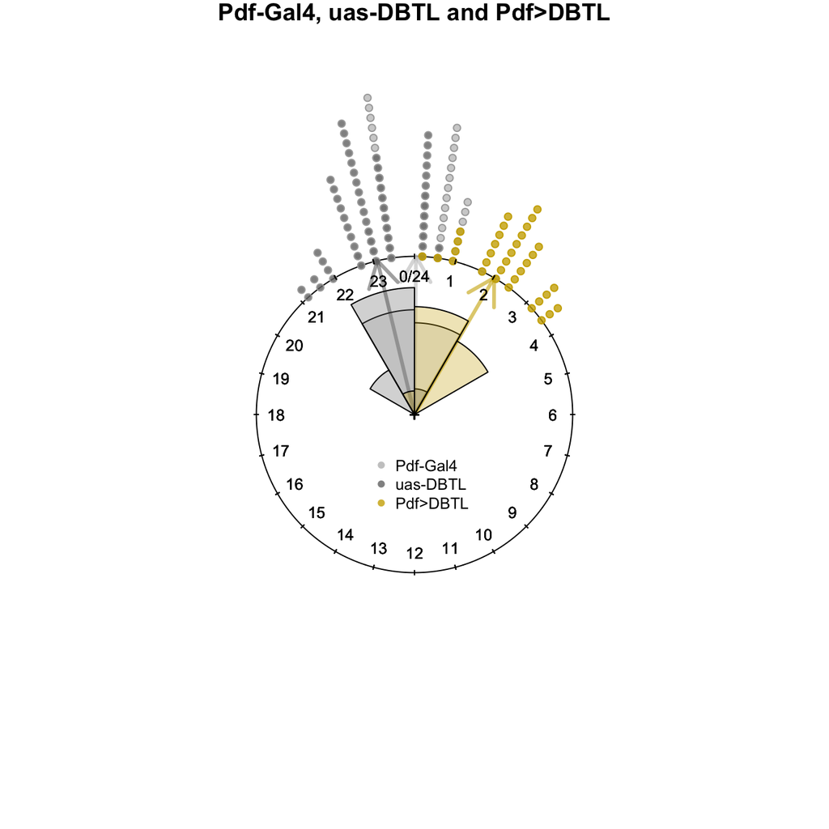

```r
# Plot 2
par(mar=c(rep(1,4))) # set plot margins
# plot the circular data for Pdf-Gal4 [1] as a histogram with stack = TRUE
plot(cirradphases[,1], stack = TRUE, pch = 21, bg = alpha("gray77",0.8), col="darkgray",cex=0.8, sep = 0.08,
     shrink = 2.2, main="Pdf-Gal4, uas-DBTL and Pdf>DBTL", cex.main=0.8) # plot PdfGal4 [,1]

# calculate the circular means and point to them by arrows
circ.mean1<-mean(cirradphases[,1],na.rm = TRUE) # Pdf-Gal4 [1]
circ.mean4<-mean(cirradphases[,4],na.rm = TRUE) # uas-DBTL [4]
circ.mean6<-mean(cirradphases[,6],na.rm = TRUE) # Pdf>DBTL [6]

# adding points for uas-DBTL [4] and pdf>DBTL [6]
points(cirradphases[,4],stack = TRUE, pch = 21, bg = alpha("gray45",0.8), col = "darkgray", cex=0.8, sep=0.08)
points(cirradphases[,6],stack=TRUE, pch = 21, bg = alpha("gold3",0.8), col = "gold3", cex=0.8, sep=0.08)

# adding arrows to circular means
arrows.circular(circ.mean1, col = alpha("gray77",0.6), lwd=3) # arrow to circ. mean
arrows.circular(circ.mean4, col = alpha("gray45",0.6), lwd=3) # arrow to circ. mean
arrows.circular(circ.mean6, col = alpha("gold3",0.6), lwd=3) # arrow to circ. mean
legend(-0.3,-0.2,legend=c("Pdf-Gal4", "uas-DBTL","Pdf>DBTL"),
       col=c(alpha("gray77",0.9),alpha("gray45",0.8),alpha("gold3",0.8)),pch=16,cex=0.8,box.lty=0)
# Rose diagrams
rose.diag(cirradphases[,1],bins=12,col=alpha("gray77",0.3),cex=0.8,prop=0.88,add=TRUE,ticks=FALSE)
rose.diag(cirradphases[,4],bins=12,col=alpha("gray45",0.3),cex=0.8,prop=0.88,add=TRUE,ticks=FALSE)
rose.diag(cirradphases[,6],bins=12,col=alpha("gold3",0.3),cex=0.8,prop=0.88,add=TRUE,ticks=FALSE)
```

# Plot 3: Pdf>DBTL, uas-UNC5 and pdf>DBTL,UNC5

In this figure, we show the raw circular data plots and rose diagrams of **Pdf>DBTL**, **uas-UNC5** and **pdf>DBTL,UNC5** based on the angles in radians, obtained from the phases.

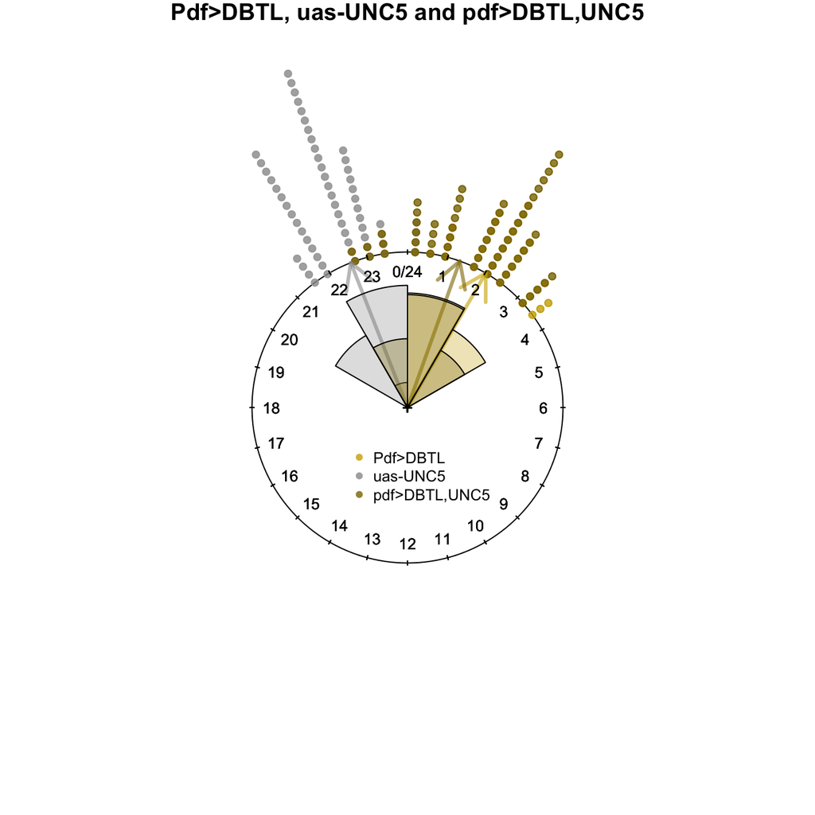

```r
# Plot 3
par(mar=c(rep(1,4)))
# plot the circular data for Pdf>DBTL [6] as a histogram with stack = TRUE
plot(cirradphases[,6], stack = TRUE, pch = 21, bg = alpha("gold3",0.8), col="gold3",cex=0.8, sep = 0.08,
     shrink = 2.2, main="Pdf>DBTL, uas-UNC5 and pdf>DBTL,UNC5", cex.main=0.8)

# calculate the circular means and point to them by arrows
circ.mean6<-mean(cirradphases[,6],na.rm = TRUE) # Pdf>DBTL [6]
circ.mean2<-mean(cirradphases[,2],na.rm = TRUE) # uas-UNC5 [2]
circ.mean7<-mean(cirradphases[,7],na.rm = TRUE) # pdf>DBTL,UNC5 [7]

# adding points for uas-UNC5 [2] and pdf>DBTL,UNC5 [7]
points(cirradphases[,2],stack = TRUE, pch = 21, bg = alpha("gray60",0.8), col = "darkgray", cex=0.8, sep=0.08)
points(cirradphases[,7],stack=TRUE, pch = 21, bg = alpha("gold4",0.8), col = "gold4", cex=0.8, sep=0.08)

# adding arrows to circular means
arrows.circular(circ.mean6, col = alpha("gold3",0.6), lwd=3) # arrow to circ. mean
arrows.circular(circ.mean2, col = alpha("gray60",0.6), lwd=3) # arrow to circ. mean
arrows.circular(circ.mean7, col = alpha("gold4",0.6), lwd=3) # arrow to circ. mean
legend(-0.4,-0.2,legend=c("Pdf>DBTL", "uas-UNC5","pdf>DBTL,UNC5"),
       col=c(alpha("gold3",0.8),alpha("gray60",0.8),alpha("gold4",0.8)),pch=16,cex=0.8,box.lty=0)
# Rose diagrams
rose.diag(cirradphases[,6],bins=12,col=alpha("gold3",0.3),cex=0.8,prop=0.95,add=TRUE,ticks=FALSE)
rose.diag(cirradphases[,2],bins=12,col=alpha("gray60",0.3),cex=0.8,prop=0.95,add=TRUE,ticks=FALSE)
rose.diag(cirradphases[,7],bins=12,col=alpha("gold4",0.3),cex=0.8,prop=0.95,add=TRUE,ticks=FALSE)
```

# Plot 4: Pdf>DBTL, uas-DBTL and pdf>DBTL,UNC5

In this figure, we show the raw circular data plots and rose diagrams of Pdf>DBTL, uas-DBTL and pdf>DBTL,UNC5, based on the angles in radians, obtained from the phases.

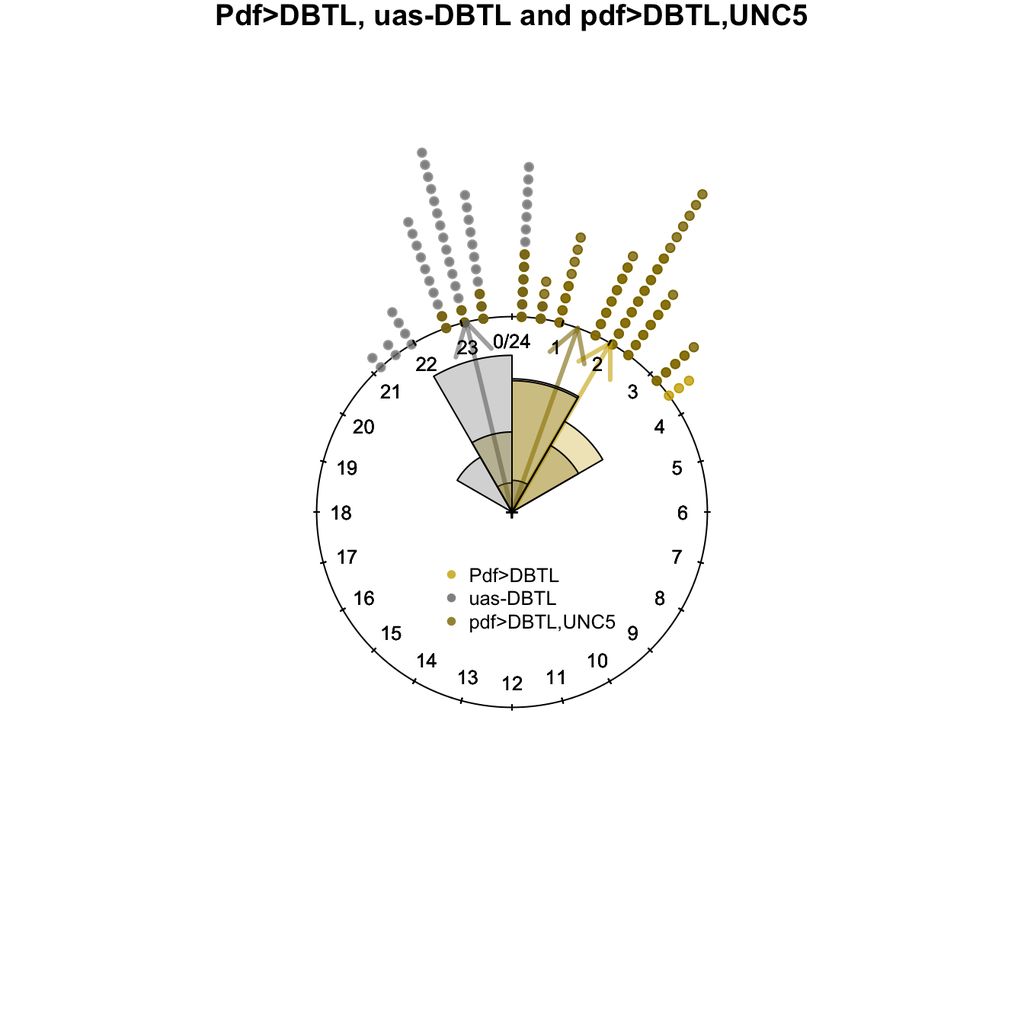

```r
# Plot 4
par(mar=c(rep(1,4))) # set margins for the plots
# plot the circular data for Pdf>DBTL [6] as a histogram with stack = TRUE
plot(cirradphases[,6], stack = TRUE, pch = 21, bg = alpha("gold3",0.8), col="gold3",cex=0.8, sep = 0.08,
     shrink = 2.2,main="Pdf>DBTL, uas-DBTL and pdf>DBTL,UNC5", cex.main=0.8)

# calculate the circular means and point to them by arrows
circ.mean6<-mean(cirradphases[,6],na.rm = TRUE) # Pdf>DBTL [6]
circ.mean4<-mean(cirradphases[,4],na.rm = TRUE) # uas-DBTL [4]
circ.mean7<-mean(cirradphases[,7],na.rm = TRUE) # pdf>DBTL,UNC5 [7]

# adding points for uas-DBTL [4] and pdf>DBTL,UNC5 [7]
points(cirradphases[,4],stack = TRUE, pch = 21, bg = alpha("gray45",0.8), col = "darkgray",cex=0.8, sep=0.08)
points(cirradphases[,7],stack=TRUE, pch = 21, bg = alpha("gold4",0.8), col = "gold4",cex=0.8, sep=0.08)

# adding arrows to circular means
arrows.circular(circ.mean6, col = alpha("gold3",0.6), lwd=3) # arrow to circ. mean
arrows.circular(circ.mean4, col = alpha("gray45",0.6), lwd=3) # arrow to circ. mean
arrows.circular(circ.mean7, col = alpha("gold4",0.6), lwd=3) # arrow to circ. mean
legend(-0.4,-0.2,legend=c("Pdf>DBTL", "uas-DBTL","pdf>DBTL,UNC5"),
       col=c(alpha("gold3",0.8), alpha("gray45",0.8),alpha("gold4",0.8)),pch=16,cex=0.8,box.lty=0)
# Rose diagrams
rose.diag(cirradphases[,6],bins=12,col=alpha("gold3",0.3),cex=0.8,prop=0.88,add=TRUE,ticks=FALSE)
rose.diag(cirradphases[,4],bins=12,col=alpha("gray45",0.3),cex=0.8,prop=0.88,add=TRUE,ticks=FALSE)
rose.diag(cirradphases[,7],bins=12,col=alpha("gold4",0.3),cex=0.8,prop=0.88,add=TRUE,ticks=FALSE)
```